Exploring requests between 2018-10-29 and 2018-11-05.

There were a total of 252689 requests intercepted by mitmproxy and 44104 requests which were not intercepted.

That makes a total of 296793 requests for the period which is 29.44375 per minute on average.

This is what requests by 15 min block look like.

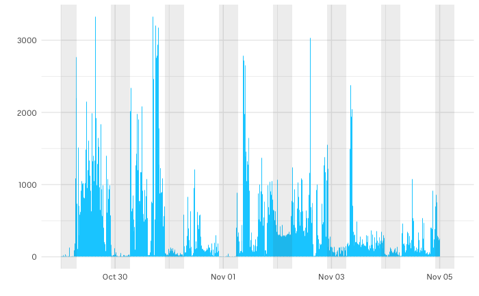

```r
nights <- tribble(
  ~start, ~end,
  start, start + hours(7),
  start + days(1) - hours(2), start + days(1) + hours(6) + minutes(30),
  start + days(2) - hours(2), start + days(2) + hours(6) + minutes(30),
  start + days(3) - hours(2), start + days(3) + hours(6) + minutes(30),
  start + days(4) - hours(2), start + days(4) + hours(6) + minutes(30),
  start + days(5) - hours(2), start + days(5) + hours(6) + minutes(30),
  start + days(6) - hours(2), start + days(6) + hours(6) + minutes(30),
  start + days(7) - hours(2), start + days(7) + hours(6) + minutes(30)
)
layer_data(plot_requests_histogram()) %>% select(y, b=xmin) %>% mutate(b=b-1540735200) %>% jsonlite::write_json(here::here('data','exports','requests-histogram.json'))
plot_requests_histogram() + geom_rect(data = nights, aes(xmin = start, xmax = end, ymin = -Inf, ymax = Inf), alpha = 0.1, inherit.aes = F)
```

Lets take a look at the period on the second night of data when I know I was sleeping and which is pretty quiet.

```
the condition has length > 1 and only the first element will be used
```

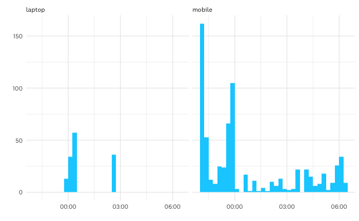

```r
requests_second_night <- get_requests_common() %>% filter(timestamp %within% interval(start + days(1) - hours(2), start + days(1) + hours(6) + minutes(30)))
requests_second_night %>% count(domain) %>% arrange(desc(n)) %>% head(15) %>% write_csv(here::here('data','exports','second-night-top-domains.csv'))
plot_requests_histogram(requests_second_night, binwidth = 900) + facet_grid(. ~ device)
```

What about by domain?

```r
requests_second_night %>% count(domain) %>% arrange(desc(n))
```

| domain | n |
| --- | --- |
| apple.com | 186 |
| icloud.com | 145 |
| twimg.com | 88 |
| twitter.com | 86 |
| nytimes.com | 55 |
| content-storage-upload.googleapis.com | 44 |
| google.com | 36 |
| nyt.com | 32 |
| dropbox.com | 21 |
| overcast.fm | 14 |

[output cut: 36 more lines]

During that period there were 841 requests to 46 companies.

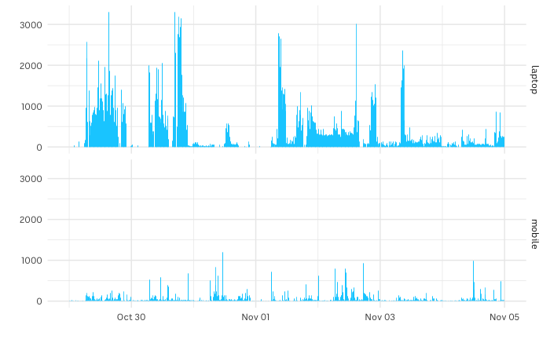

```r
plot_requests_histogram() + facet_grid(device ~ .)
```

You can see from the plot above that my laptop makes vastly more requests than my phone.

```r
get_requests_common() %>% mutate(day=floor_date(timestamp, 'day'), hour=hour(timestamp), minute = minute(timestamp)) %>% group_by(device, day, hour, minute) %>% count() %>% arrange(desc(n))
```

| device | day | hour | minute | n |
| --- | --- | --- | --- | --- |
| mobile | 2018-11-04 | 11 | 45 | 912 |
| laptop | 2018-11-02 | 21 | 0 | 657 |
| laptop | 2018-10-29 | 16 | 13 | 649 |
| mobile | 2018-11-01 | 6 | 7 | 624 |
| laptop | 2018-11-02 | 14 | 42 | 622 |
| mobile | 2018-10-30 | 21 | 47 | 609 |
| laptop | 2018-11-02 | 14 | 41 | 585 |
| laptop | 2018-10-30 | 16 | 38 | 568 |
| mobile | 2018-11-02 | 0 | 12 | 549 |
| laptop | 2018-11-02 | 20 | 47 | 535 |

[output cut: 990 more lines]

## User agents

| value | n |
| --- | --- |
| Mozilla/5.0 (Macintosh; Intel Mac OS X 10_13_6) AppleWebKit/537.36 (KHTML, like Gecko) Chrome/70.0.3538.77 Safari/537.36 | 84674 |
| Chrome MAC 70.0.3538.77 (0f6ce0b0cd63a12cb4eccea3637b1bc9a29148d9-refs/branch-heads/3538@{#1039}) channel(stable) | 35986 |
| Airmail 3.6.50 rv:528 (Macintosh; Mac OS X 10.13.6; en_AU) | 26327 |
| Tweetbot/25801 CFNetwork/902.1 Darwin/17.7.0 (x86_64) | 19786 |
| Mozilla/5.0 (Macintosh; Intel Mac OS X 10_13_6) AppleWebKit/537.36 (KHTML, like Gecko) AtomShell/3.3.3 Chrome/61.0.3163.100 Electron/2.0.7 Safari/537.36 Slack_SSB/3.3.3 | 10017 |
| Mozilla/5.0 (iPhone; CPU iPhone OS 12_0_1 like Mac OS X) AppleWebKit/605.1.15 (KHTML, like Gecko) Version/12.0 Mobile/15E148 Safari/604.1 | 9597 |
| Tweetbot/50200 CFNetwork/974.2.1 Darwin/18.0.0 | 9590 |
| MacOutlook/16.18.0.181014 (Intelx64 Mac OS X Version 10.13.6 (Build 17G65)) | 6285 |
| Mozilla/5.0 (Macintosh; Intel Mac OS X 10_13_6) AppleWebKit/537.36 (KHTML, like Gecko) Teams/1.1.00.26352 Chrome/61.0.3163.100 Electron/2.0.10 Safari/537.36 | 5668 |
| Mozilla/4.0 (compatible; SPIPE/3.0; Windows) McAfee Agent | 4710 |

[output cut: 288 more lines]

There are 298 user-agents in the data. How many separate domains do each talk to?

Histograms for most common user-agents.

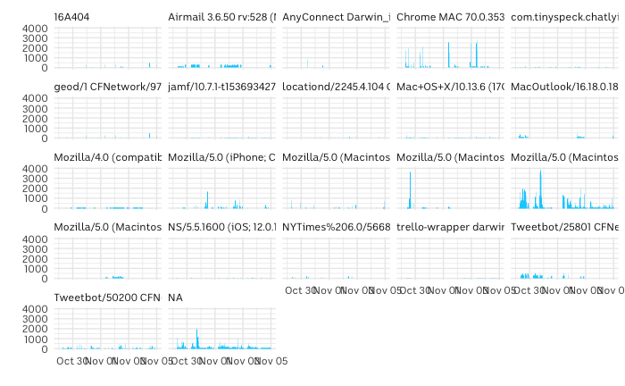

For the intercepted requests we have a full suite of request and response data including all http headers and content. For the requests we couldn’t intercept, only the request host is known.

## Domains

The first thing I want to look at is the overall counts for requests to each top level domain.

| domain | n | pct |
| --- | --- | --- |
| google.com | 55662 | 0.187544854495 |
| office365.com | 34730 | 0.117017584647 |
| twitter.com | 25495 | 0.085901621669 |
| abc.net.au | 14230 | 0.047945874734 |
| twimg.com | 13833 | 0.046608242108 |
| apple.com | 11731 | 0.039525864828 |
| chartbeat.com | 10906 | 0.036746149673 |
| slack-msgs.com | 7258 | 0.024454754661 |
| microsoft.com | 6442 | 0.021705363671 |
| runkit.com | 6439 | 0.021695255616 |

[output cut: 990 more lines]

Google is, by a fair margin, the most talked to domain representing 19% of requests. The main surprise in that list is runkit.com.

| company_name | n | pct |
| --- | --- | --- |
| NA | 82671 | 0.278547674642 |
| Google | 68748 | 0.231636190881 |
| Microsoft | 42632 | 0.143642201804 |
| Twitter | 39424 | 0.132833321541 |
| ChartBeat | 13126 | 0.044226110454 |
| Apple | 11731 | 0.039525864828 |
| GitHub, Inc. | 4939 | 0.016641228061 |
| Verizon | 2954 | 0.009953064931 |
| RTL Group | 2689 | 0.009060186729 |
| Facebook | 1900 | 0.006401768236 |

[output cut: 234 more lines]

| domain | host | n |
| --- | --- | --- |
| google.com | clients4.google.com | 36439 |
| google.com | 0.docs.google.com | 4369 |
| google.com | play.google.com | 3313 |
| google.com | logging.clients6.google.com | 2762 |
| gstatic.com | ssl.gstatic.com | 1858 |
| google.com | docs.google.com | 1366 |
| google-analytics.com | www.google-analytics.com | 1265 |
| google.com | clients6.google.com | 1261 |
| googleusercontent.com | apidata.googleusercontent.com | 955 |
| doubleclick.net | googleads.g.doubleclick.net | 791 |

[output cut: 191 more lines]

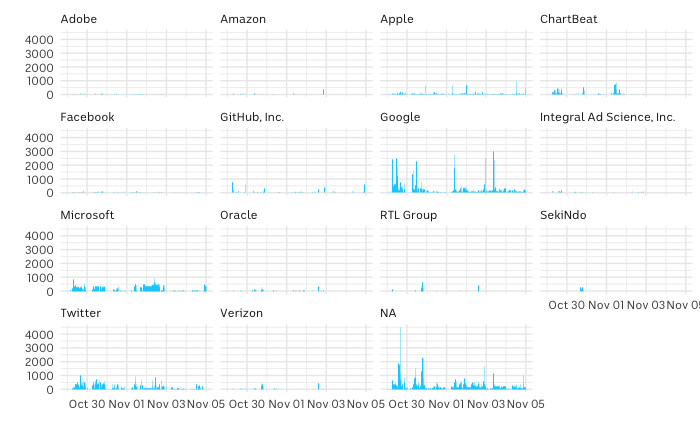

| domain | n |
| --- | --- |
| abc.net.au | 14230 |
| slack-msgs.com | 7258 |
| runkit.com | 6439 |
| icloud.com | 5518 |
| slack.com | 4459 |
| nytimes.com | 2562 |
| hypothes.is | 2536 |
| 10.25.216.57 | 1659 |
| 10.136.56.36 | 1657 |
| I-0CEC80AF3B5A2 | 1657 |

[output cut: 788 more lines]